# Interpretabilidad

#### Importamos las librerias

```python
import numpy as np
import pandas as pd
import scikitplot as skplt
import pickle
import shap

shap.initjs()
```

Cargamos las variables train y test

```python
X_train_lasso = pd.read_parquet("Data/X_train_lasso.parquet")
y_train = pd.read_parquet("Data/y_train.parquet")
X_test_lasso = pd.read_parquet("Data/X_test_lasso.parquet")
y_test = pd.read_parquet("Data/y_test.parquet")
```

### SHAP

Cargamos el modelo LightGBM, que es compatible con la librería SHAP para buscar la interpretabilidad del modelo.

Hemos tenido que descartar el modelo Gradient Boosting porque no es interpretable y no esta disponible para aplicarle SHAP.

```python
with open('Data/LightGBM.pkl', 'rb') as f:
    lightgbm = pickle.load(f)
```

[output not shown]

```python
model_selected = lightgbm
```

```python
shap_values = shap.TreeExplainer(model_selected).shap_values(X_test_lasso)
```

Guardamos el shap_values resultante de aplicar SHAP al modelo LightGBM para no tener que ejecutarlo mas veces y lo cargamos para no tener que volver a ejecutarlo.

```python
with open('Data/shap_values.pkl', 'wb') as f:

    pickle.dump(shap_values, f)
```

```python
with open('Data/shap_values.pkl', 'rb') as f:

    shap_values = pickle.load(f)
```

#### Importacia de las carecteristicas del accidente

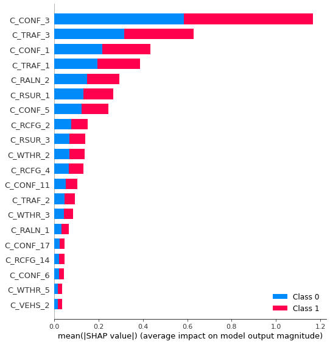

```python
shap.summary_plot(shap_values, X_test_lasso)
```

Leyenda de las caracteristicas con mayor influencia en el modelo:

- C_CONF_3: Salida por el arcen izquierdo
- C_TRAF_3: Paso de peatones
- C_CONF_1: Colision con objeto en movimiento (persona, animal...)
- C_TRAF_1: Señal de trafico operativa
- C_RALN_2: Calzada recta con pendiente
- C_RSUR_1: Calzada seca, normal
- C_CONF_5: El vehiculo realiza vueltas de campana
- C_RCFG_2: Interseccion, al menos dos vias publicas
- C_RSUR_3: Calzada con nieve o hielo
- C_WTHR_2: Nublado sin precipitaciones

Esta primera grafica de SHAP muestra la representatividad de las etiquetas respecto a la varaible target, en nuestro caso binaria, 0: non_fatality, 1: fatality.

#### Grafico resumen SHAP

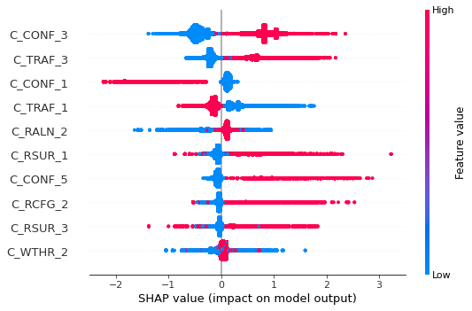

```python
shap.summary_plot(shap_values[0], features = X_test_lasso, max_display=10)
```

El grafico de resumen combina la importancia de las caracteristicas con los valores de evaluacion que toma SHAP para cada una de ellas. El eje X ilustra los valores positivos o negativos que aporta SHAP, y el eje Y indica las importancia de las variables.

Destacamos las diferentes valoraciones que da SHAP a las variables C_CONF y C_TRAF, que son las que influyen en la probabilidad de fatality, dependiendo del valor que adopa la variable.